# R: Exploration of data with Visualization

Kushal K Dey

July 28, 2016

In this script, we shall breifly go over visualization in R.

## Simple Scatter Plot

We consider some basic plotting tools here.

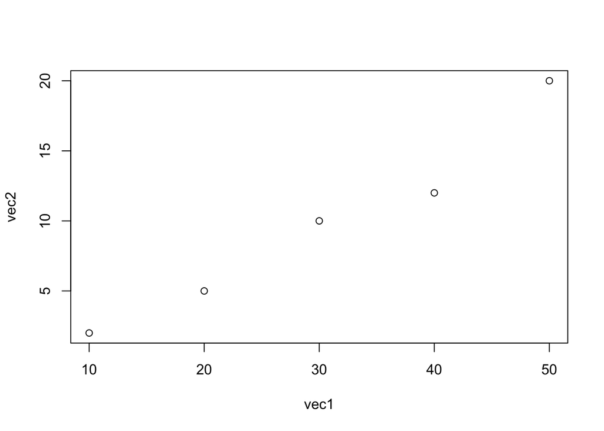

```r
vec1 <- c(10, 20, 30, 40, 50);
vec2 <- c(2, 5, 10, 12, 20);
plot(vec1, vec2)
```

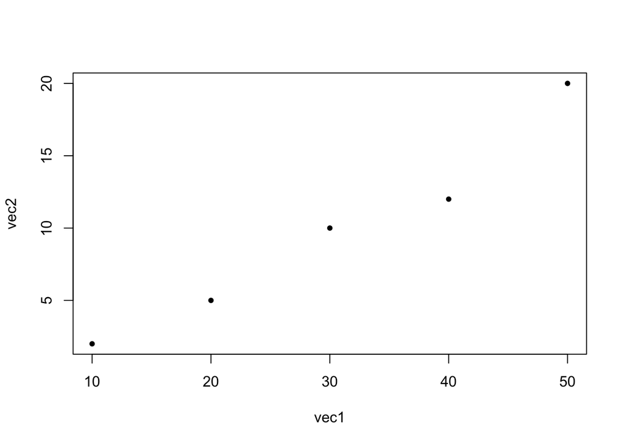

```r
## shape of the points determination in the plot

plot(vec1, vec2, pch=20)
```

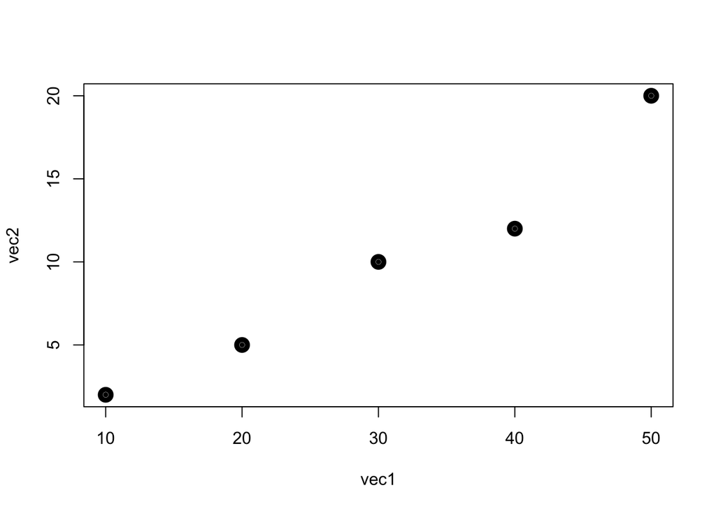

```r
## line width of the points in the plot

plot(vec1, vec2, pch=20, lwd=10)
```

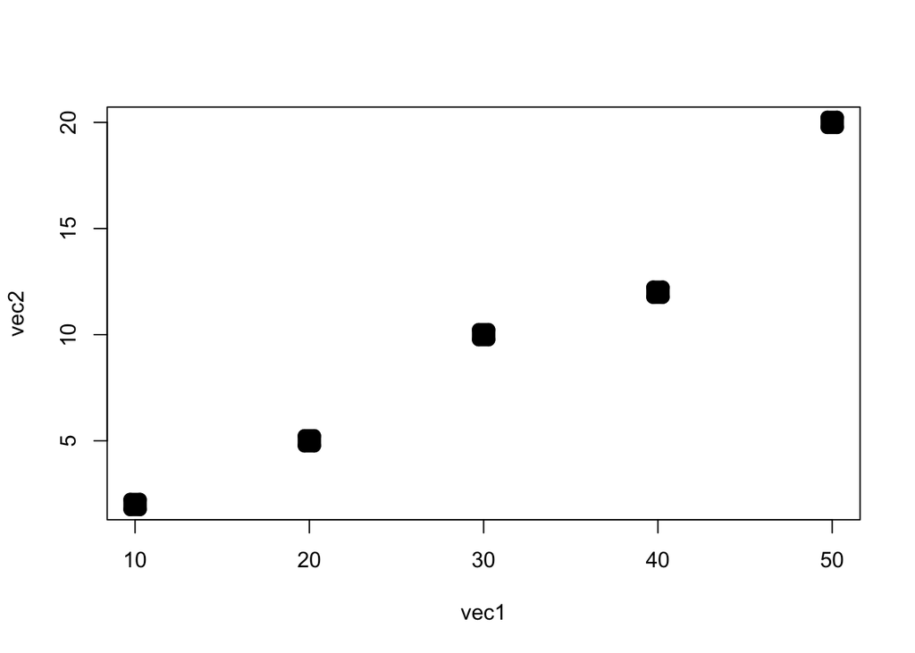

```r
plot(vec1, vec2, pch=7, lwd=10)
```

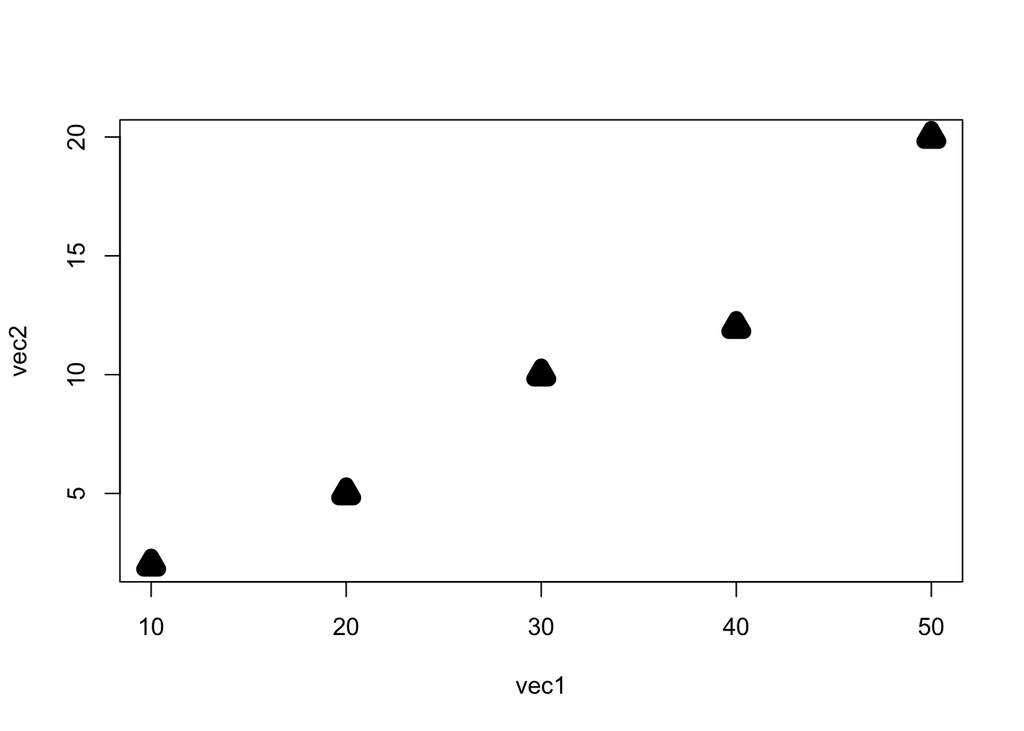

```r
plot(vec1, vec2, pch=2, lwd=10)
```

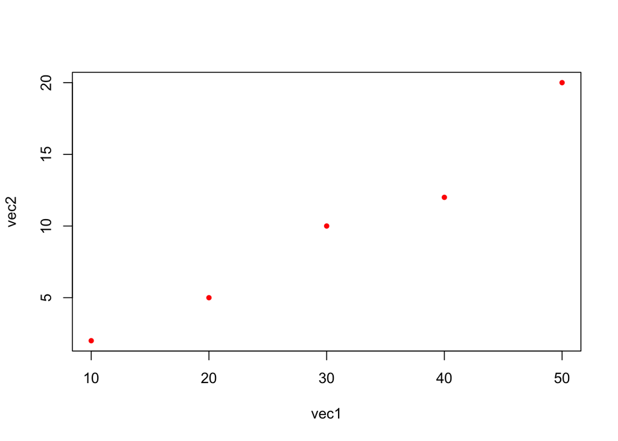

```r
## What pch to choose...look up documentation

?pch

## color the points

plot(vec1, vec2, pch=20, lwd=1, col="red")
```

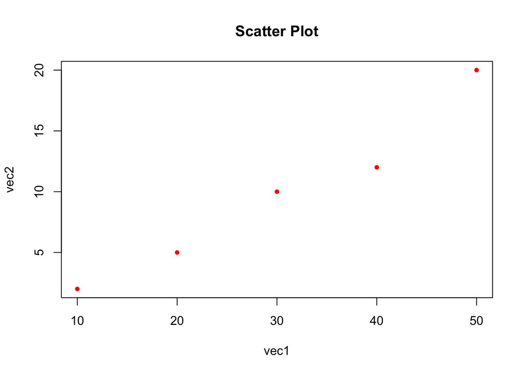

```r
## Add title to the plot

plot(vec1, vec2, pch=20, lwd=1, col="red", main="Scatter Plot")
```

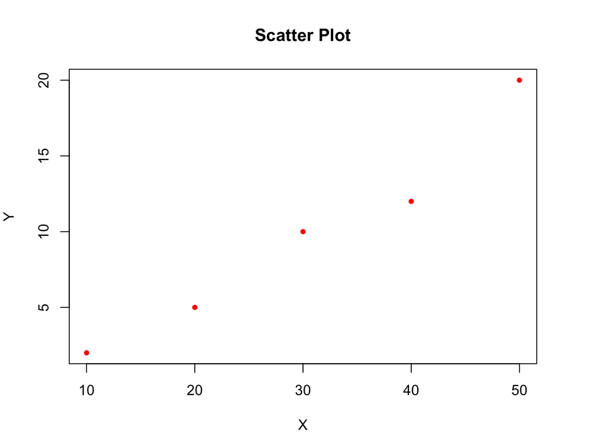

```r
##  Fix the margin of the plot
par(mar=c(4,4,4,4))
plot(vec1, vec2, pch=20, lwd=1, col="red", main="Scatter Plot",
     xlab="X", ylab="Y")

## A new margin of the plot

par(mar=c(8,5,5,5))
plot(vec1, vec2, pch=20, lwd=1, col="red", main="Scatter Plot",
     xlab="X", ylab="Y")

par(mar=c(4,4,4,4))
plot(vec1, vec2, pch=20, lwd=1, col="red", main="Scatter Plot",
     xlab="X", ylab="Y")
```

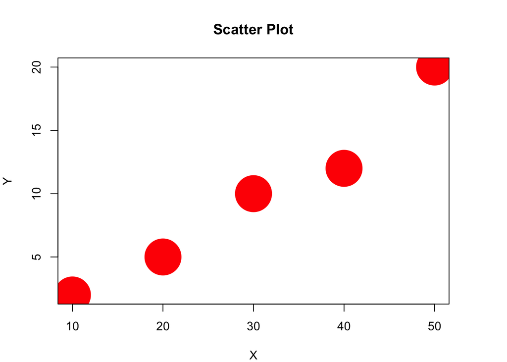

```r
## control size of the points in the plot

plot(vec1, vec2, pch=20, lwd=1, col="red", cex=10, main="Scatter Plot", xlab="X", ylab="Y")
```

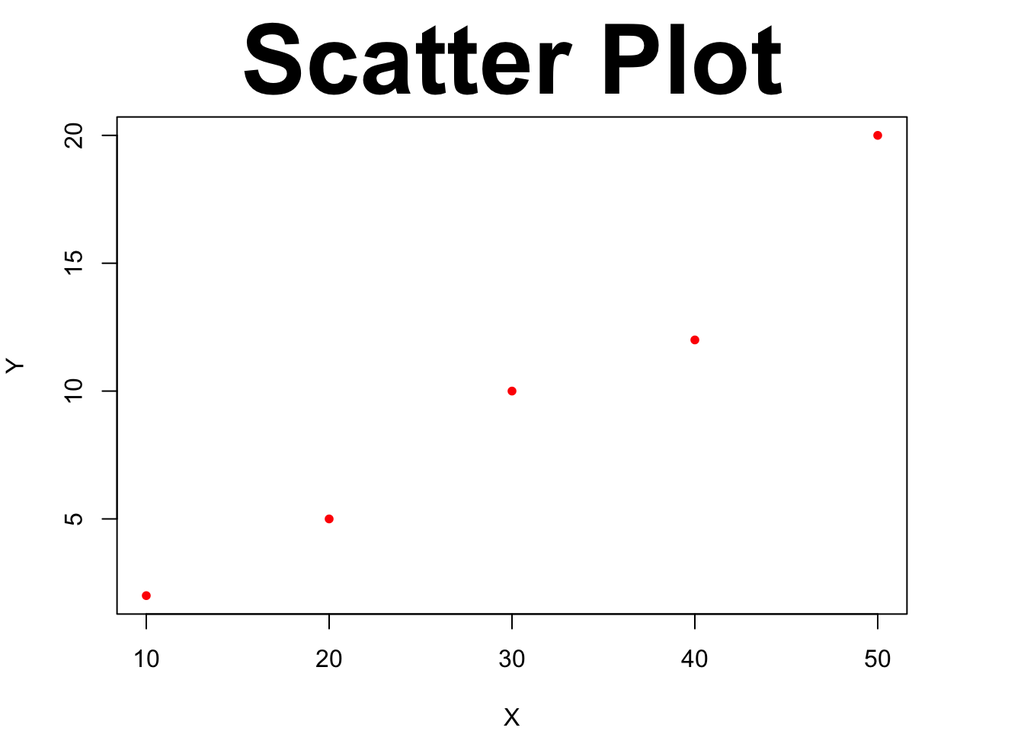

```r
## cex.main controls the size of the title

plot(vec1, vec2, pch=20, lwd=1, col="red", cex=1, main="Scatter Plot", xlab="X", ylab="Y", cex.main=4)
```

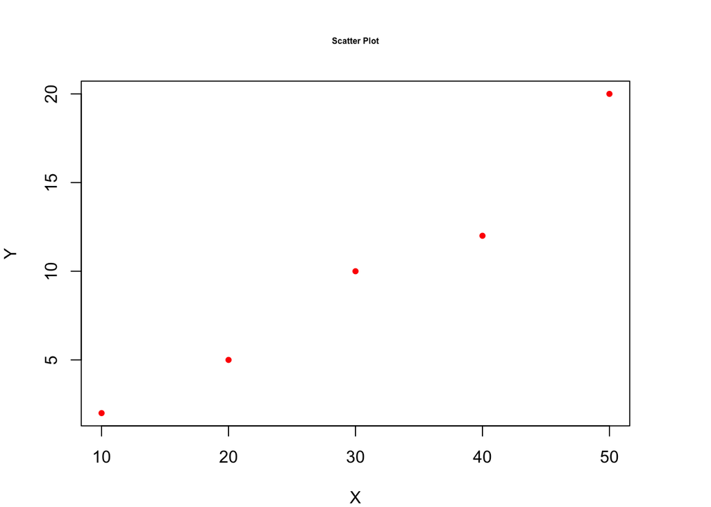

```r
plot(vec1, vec2, pch=20, lwd=1, col="red", cex=1, main="Scatter Plot", xlab="X", ylab="Y", cex.main=0.5)
```

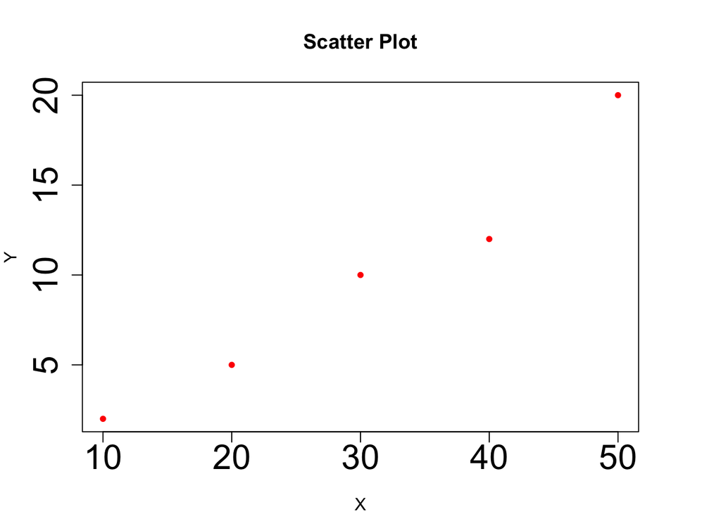

```r
## cex.axis controls the size of the axis labels

plot(vec1, vec2, pch=20, lwd=1, col="red", cex=1, main="Scatter Plot", xlab="X", ylab="Y", cex.axis=2)
```

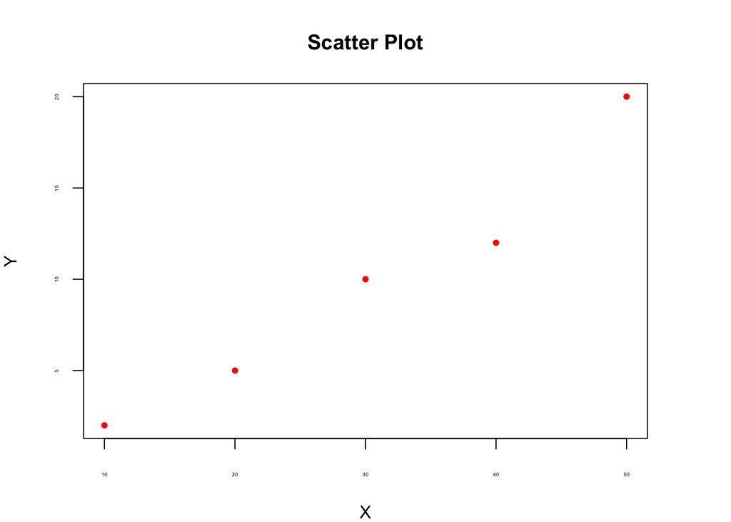

```r
plot(vec1, vec2, pch=20, lwd=1, col="red", cex=1, main="Scatter Plot", xlab="X", ylab="Y", cex.axis=0.3)
```

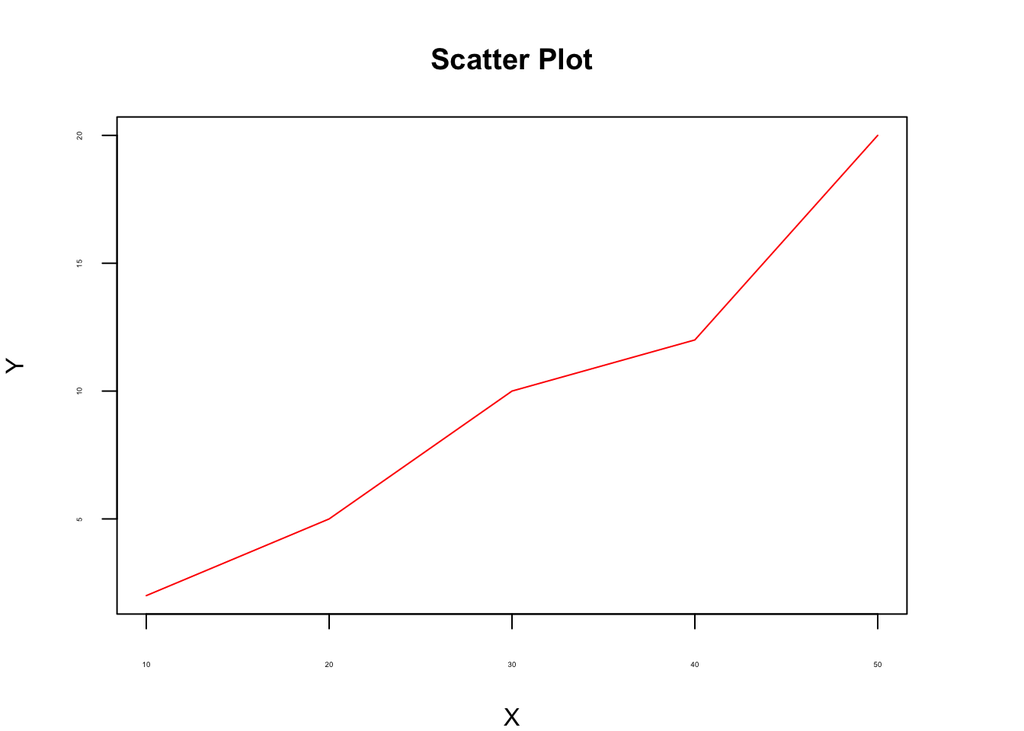

```r
## if you want a line plot instead of scatter plot

plot(vec1, vec2, pch=20, lwd=1, col="red", cex=1, main="Scatter Plot", xlab="X", ylab="Y", cex.axis=0.3, type="l")
```

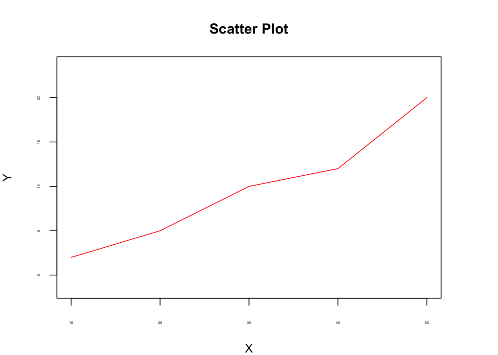

```r
## fix aspect ratio

plot(vec1, vec2, pch=20, lwd=1, col="red", cex=1, main="Scatter Plot", xlab="X", ylab="Y", cex.axis=0.3, type="l", asp=1)
```

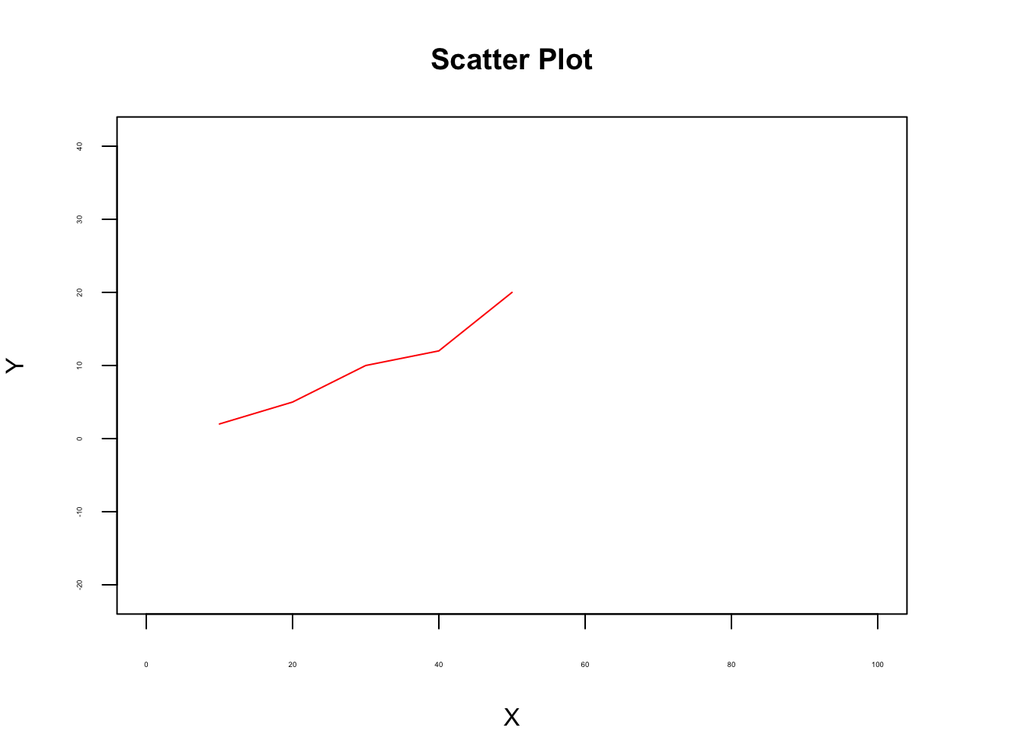

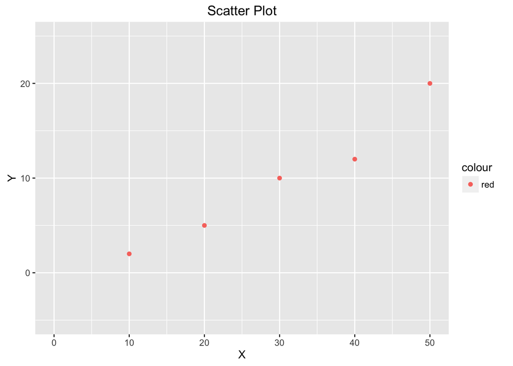

```r
## Fix xlim and ylim

plot(vec1, vec2, pch=20, lwd=1, col="red", cex=1, main="Scatter Plot", xlab="X", ylab="Y", cex.axis=0.3, type="l", asp=1,
     xlim=c(0,100), ylim=c(-20,40))

## For fancier looking plot, use qplot() of package ggplot2

ggplot2::qplot(vec1, vec2, col="red", main="Scatter Plot", xlab="X", ylab="Y", xlim=c(0,50), ylim=c(-5,25))
```

## Multiple plots in same frame

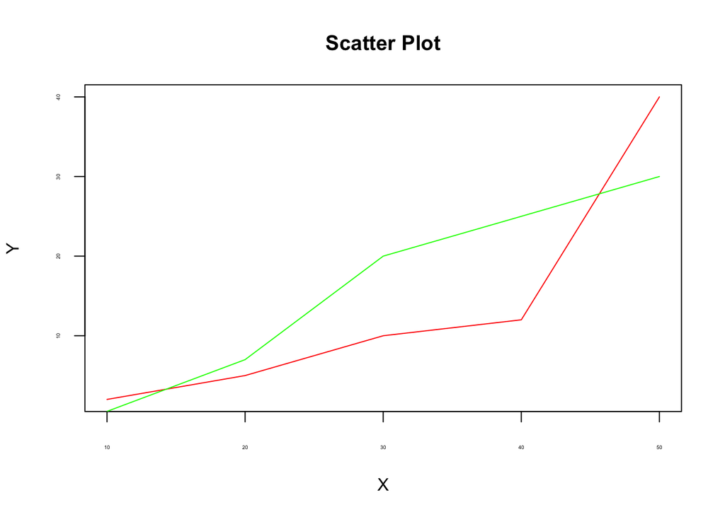

```r
vec1 <- c(10, 20, 30, 40, 50);
vec2 <- c(2, 5, 10, 12, 40);
vec3 <- c(0.5, 7, 20, 25, 30);

plot(vec1, vec2, pch=20, lwd=1, col="red", cex=1, main="Scatter Plot", xlab="X", ylab="Y", cex.axis=0.3, type="l")
points(vec1, vec3, pch=20, lwd=1, col="green", cex=1, main="Scatter Plot", xlab="X", ylab="Y", cex.axis=0.3, type="l")
```

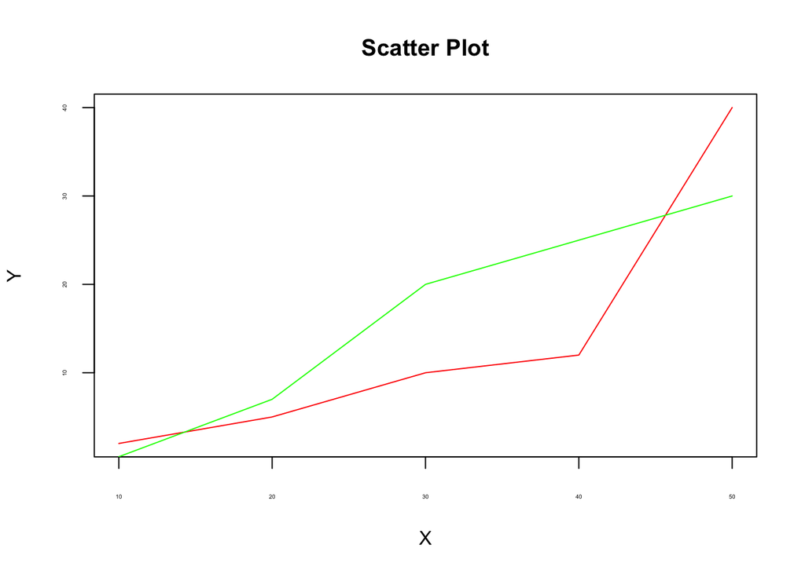

```r
## analogous

plot(vec1, vec2, pch=20, lwd=1, col="red", cex=1, main="Scatter Plot", xlab="X", ylab="Y", cex.axis=0.3, type="l")
lines(vec1, vec3, pch=20, lwd=1, col="green", cex=1, main="Scatter Plot", xlab="X", ylab="Y", cex.axis=0.3)
```

## Multiple subplots

base-R

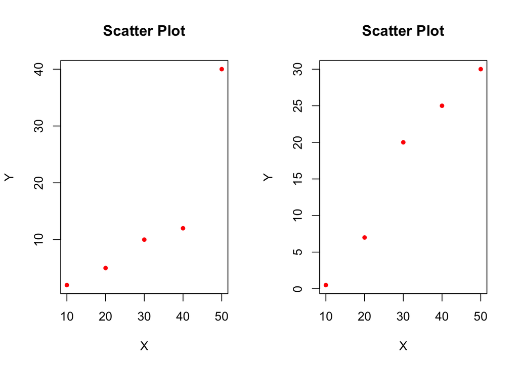

```r
par(mfrow=c(1,2))
plot(vec1, vec2, col="red", pch=20, main="Scatter Plot", xlab="X", ylab="Y")
plot(vec1, vec3, col="red", pch=20, main="Scatter Plot", xlab="X", ylab="Y")
```

ggplot2

```r
multiplot <- function(..., plotlist=NULL, cols) {
    require(grid)

    # Make a list from the ... arguments and plotlist
    plots <- c(list(...), plotlist)

    numPlots = length(plots)

    # Make the panel
    plotCols = cols                          # Number of columns of plots
    plotRows = ceiling(numPlots/plotCols) # Number of rows needed, calculated from # of cols

    # Set up the page
    grid.newpage()
    pushViewport(viewport(layout = grid.layout(plotRows, plotCols)))
    vplayout <- function(x, y)
        viewport(layout.pos.row = x, layout.pos.col = y)

    # Make each plot, in the correct location
    for (i in 1:numPlots) {
        curRow = ceiling(i/plotCols)
        curCol = (i-1) %% plotCols + 1
        print(plots[[i]], vp = vplayout(curRow, curCol ))
    }

}
```

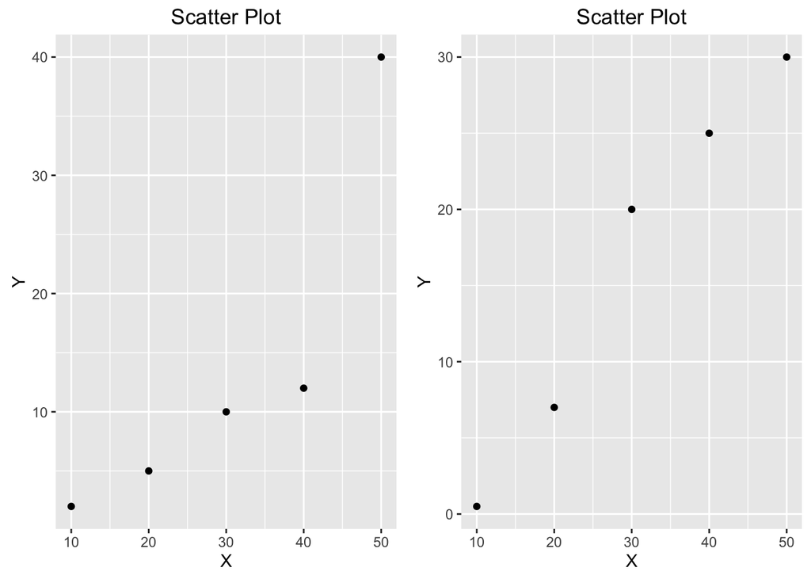

```r
plot1 <- ggplot2::qplot(vec1, vec2, main="Scatter Plot", xlab="X", ylab="Y")
plot2 <- ggplot2::qplot(vec1, vec3, main="Scatter Plot", xlab="X", ylab="Y")
multiplot(plot1, plot2, cols=2)
```

## Summary plots of data

Visualization is an important exploration tool, specially when the data size is pretty big.

```r
data(mtcars)
vec <- mtcars$qsec
```

summary plots for the *vec* data

```r
par(mfrow=c(1,1))
summary(vec)
```

```
##    Min. 1st Qu.  Median    Mean 3rd Qu.    Max.
##   14.50   16.89   17.71   17.85   18.90   22.90
```

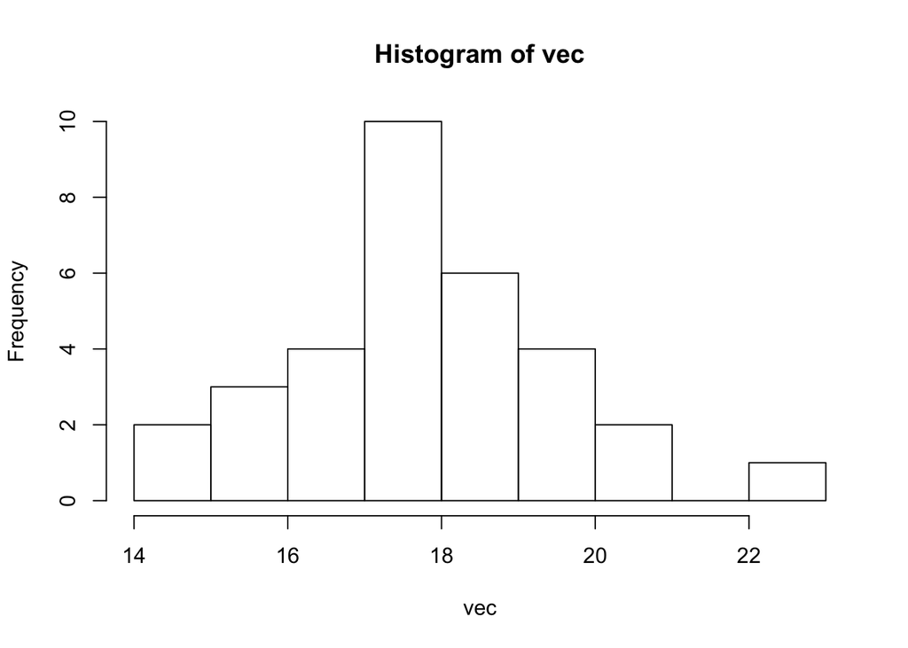

```r
hist(vec)
```

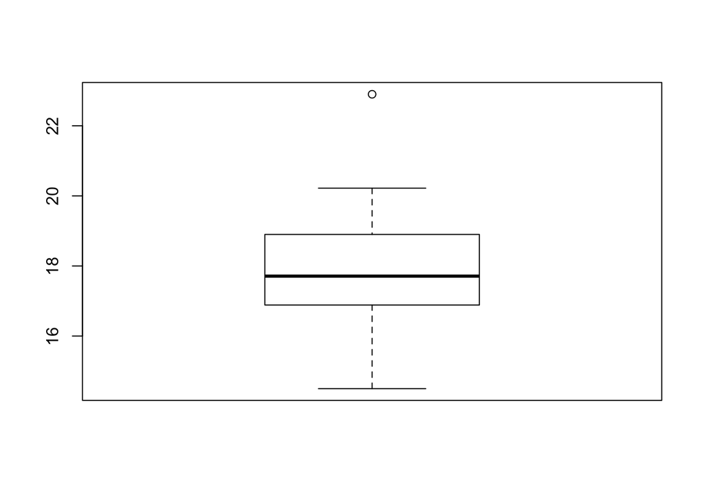

```r
boxplot(vec)
```

Suppose now we have a discrete data. We can either summarize it in a table format or make a bar chart out of it.

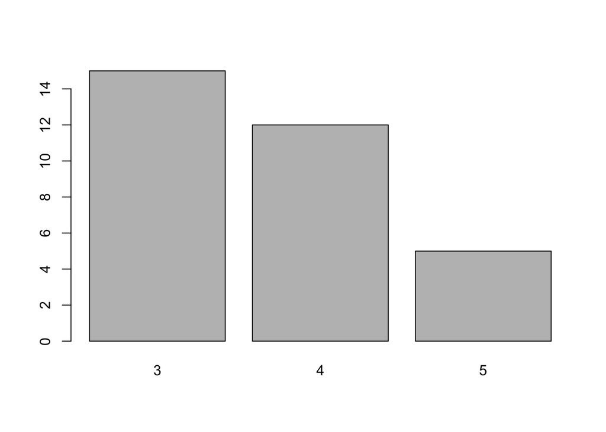

```r
gears <- mtcars$gear;
counts <- table(mtcars$gear)
barplot(counts)
```

Options like *cex*, *cex.main*, *cex.axis*, *col* and other plotting parameters are available for all these above plots, check the documentation by typing

```r
?barplot
?boxplot
?hist
```

Any histogram for continuous data can be approximated by a continuous curve passing through it. We call that the density plot for that data.

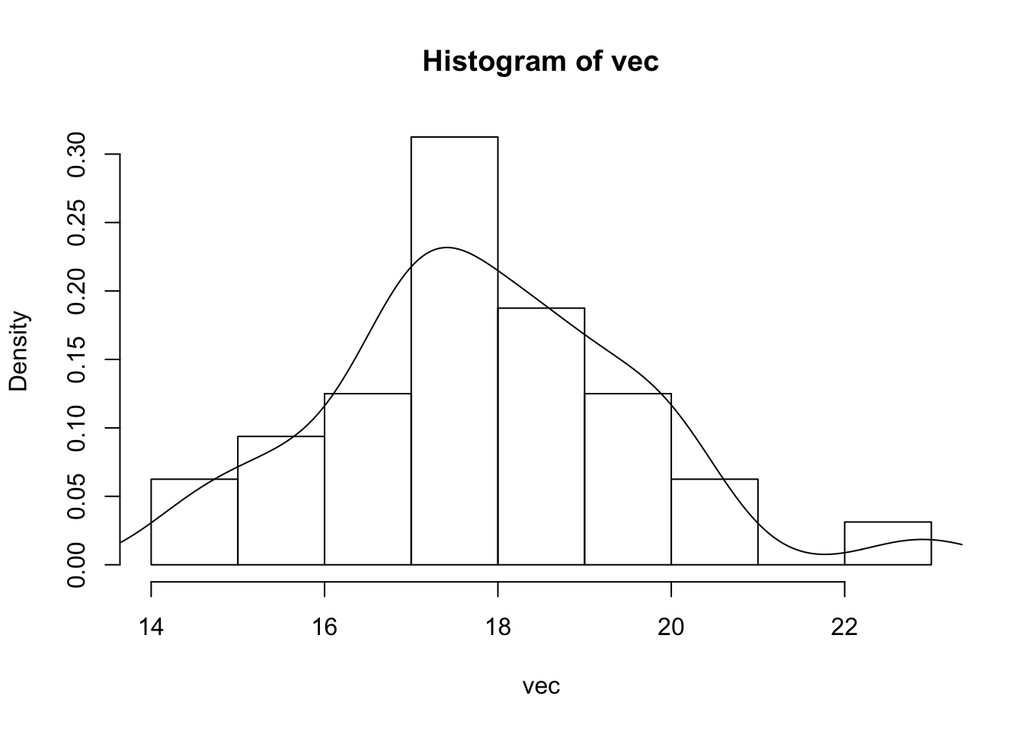

```r
hist(vec, prob=TRUE) ## scales frequencies s.t. area under curve sums to 1
points(density(vec), type="l")
```

There are some standard forms of densities in R and we usually try to map the density plots from the data to any of these forms of densities after adjusting for location and scale.

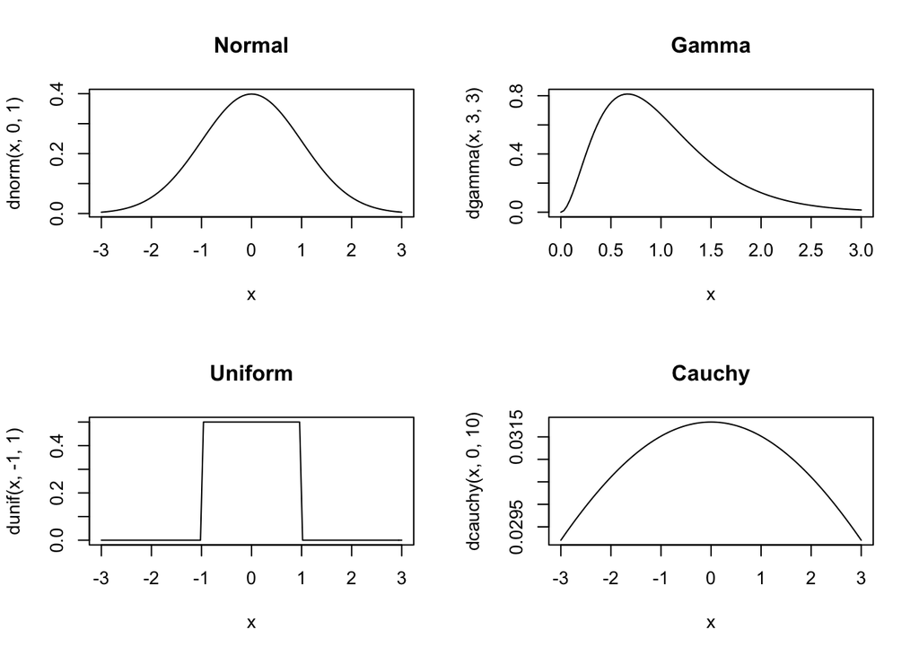

```r
par(mfrow=c(2,2))
curve(dnorm(x,0,1), from=-3, to=3, main="Normal") ## mean 0, sd 1
curve(dgamma(x,3,3), from=0, to=3, main="Gamma") ## scale and shape
curve(dunif(x,-1,1), from=-3, to=3, main="Uniform") ## start and end points
curve(dcauchy(x,0,10), from=-3, to=3, main="Cauchy") ## location and scale
```

We can simulate data from each of these density functions. Simulation means if we have enough data, the histogram will closely approximate the underlying density functions.

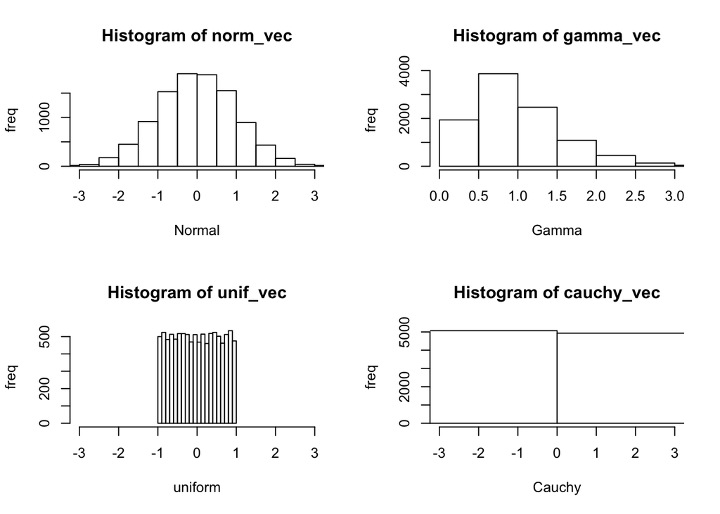

```r
norm_vec <- rnorm(10000, 0, 1);
gamma_vec <- rgamma(10000, 3, 3);
unif_vec <- runif(10000, -1, 1);
cauchy_vec <- rcauchy(10000, 0, 0.1);

par(mfrow=c(2,2))

hist(norm_vec, xlab="Normal", ylab="freq", xlim=c(-3,3))
hist(gamma_vec, xlab="Gamma", ylab="freq", xlim=c(0,3) )
hist(unif_vec, xlab="uniform", ylab="freq", xlim=c(-3,3))
hist(cauchy_vec, xlab="Cauchy", ylab="freq", xlim=c(-3,3))
```

If we want to know the density function value at each point, we use the *d…* function, if we want to know the area under the curve less than or equal to that point, we use *p…* and if we want to find the quantiles, we use *q…*

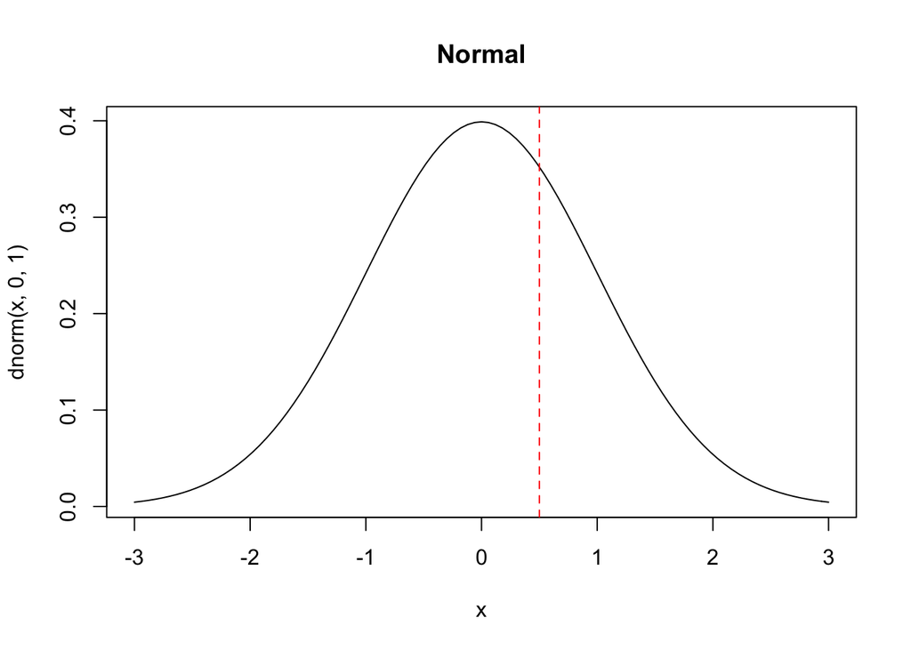

```r
par(mfrow=c(1,1))
curve(dnorm(x,0,1), from=-3, to=3, main="Normal")
abline(v = 0.5, col = "red", lty = "dashed")
```

```r
dnorm(0.5, 0, 1)
```

```
## [1] 0.3520653
```

```r
pnorm(0.5,0,1)
```

```
## [1] 0.6914625
```

```r
qnorm(0.69, 0, 1)
```

```
## [1] 0.4958503
```

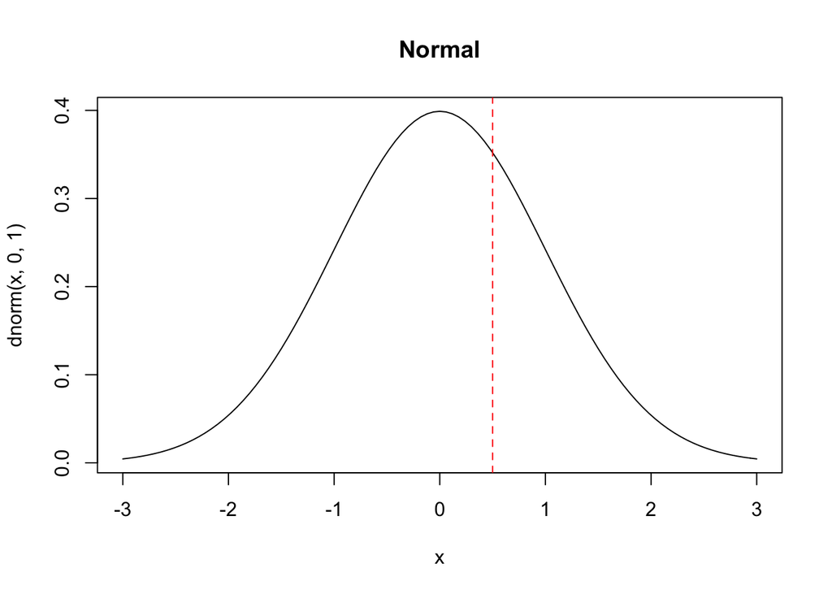

```r
curve(dnorm(x,0,1), from=-3, to=3, main="Normal")
abline(v = 0.5, col = "red", lty = "dashed")
```

```r
dnorm(0,0,1)
```

```
## [1] 0.3989423
```

```r
pnorm(0,0,1)
```

```
## [1] 0.5
```

```r
dnorm(-Inf, 0, 1)
```

```
## [1] 0
```

```r
dnorm(Inf, 0, 1)
```

```
## [1] 0
```

```r
pnorm(-Inf, 0, 1)
```

```
## [1] 0
```

```r
pnorm(Inf, 0, 1)
```

```
## [1] 1
```

Similarly we can do the same for *_unif*,* _gamma*,* _cauchy*,* _beta*,* _exp*,* _chisq* and many other contunuous density functions.

The quantile information is very crucial. We often try to match the quantiles we get from the data with the ones from these standard distributions after location and scale adjustment.

For normal case, it is very simple

```r
quantile(vec)
```

```
##      0%     25%     50%     75%    100%
## 14.5000 16.8925 17.7100 18.9000 22.9000
```

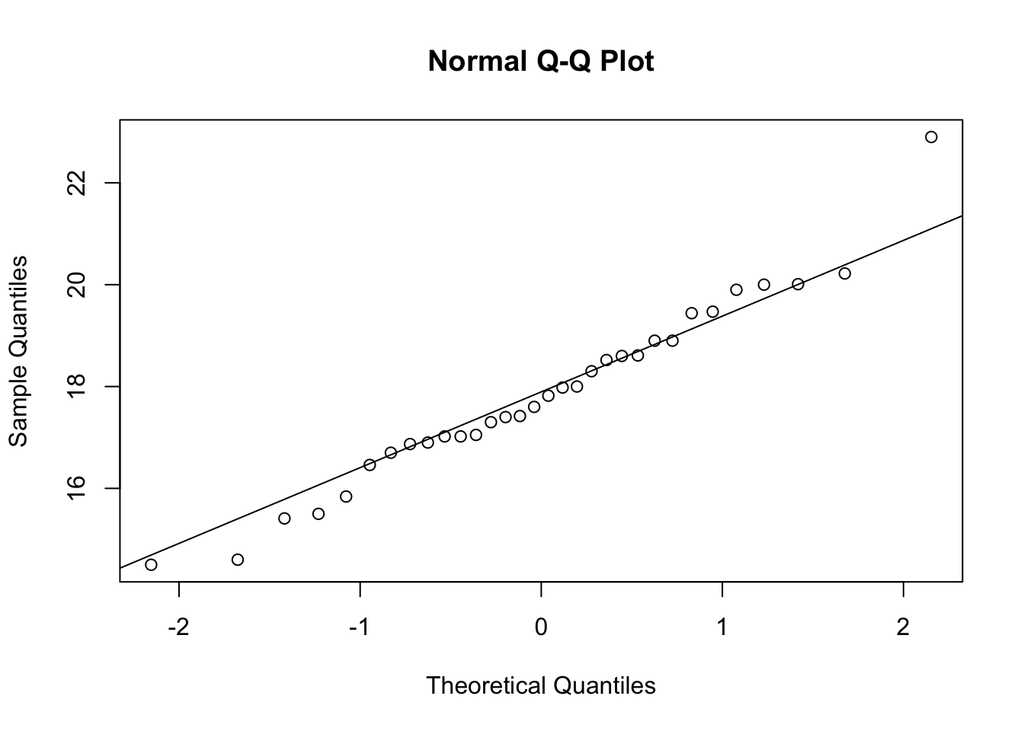

```r
qqnorm(vec)
qqline(vec)
```

These plots are called QQ plots.

There are also more formal tests that give a measure of whether the data fits a normal density map well or not. If this measure is less than $0.05$, then it is not Normal, else it is mapped well to Normal.

```r
shapiro.test(vec)
```

```
##
##  Shapiro-Wilk normality test
##
## data:  vec
## W = 0.97325, p-value = 0.5935
```

One can similarly plot QQ plots for other distributions.

```r
library(gap)
```

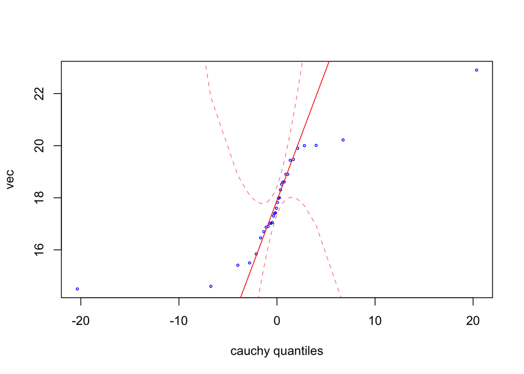

```r
qqfun(vec, distribution="cauchy")
```